## SDS 385 Report

*Akshay Kumar Varanasi (av32826)*

### Description of the data

Attribute Information:

1. ID number 2) Diagnosis (M = malignant, B = benign) 3-12)

Ten real-valued features are computed for each cell nucleus: a) radius (mean of distances from center to points on the perimeter) b) texture (standard deviation of gray-scale values) c) perimeter d) area e) smoothness (local variation in radius lengths) f) compactness (perimeter^2 / area - 1.0) g) concavity (severity of concave portions of the contour) h) concave points (number of concave portions of the contour) i) symmetry j) fractal dimension (“coastline approximation” - 1)

Class distribution: 357 benign, 212 malignant

### Question

Breast cancer is one of the most common cancer among women and one of the major causes of the death. When detected early, it can be treated effectively but when we detect in the advanced stages treatment becomes difficult. There are different diagnosis technique out of which “Fine needle aspiration(FNA) with visual interpretation” is one of them. Since visual interpretation involves human errors so it would be better if we could automate it to reduce diagnostic errors. The current dataset contains various computational interpretation of FNA like nuclei radius, area. As we can see, there are so many of them and all of them are not important. Since we want to build ML model, we want to build on good or important features. This report is about that, finding out those features.

Find out which features are important for diagnosis of Breast Cancer?

### Answer

We find the important features for diagnosis by fitting a logistic regression model and based on the model we get, we decide which are important.

Call the necessary the libraries

```r
library(ggplot2)
library(plotROC)
```

Read the data from file

```r
cancer_data = read.csv("cancer_data.csv")
head(cancer_data)
```

```
##         id diagnosis radius_mean texture_mean perimeter_mean area_mean
## 1   842302         M       17.99        10.38         122.80    1001.0
## 2   842517         M       20.57        17.77         132.90    1326.0
## 3 84300903         M       19.69        21.25         130.00    1203.0
## 4 84348301         M       11.42        20.38          77.58     386.1
## 5 84358402         M       20.29        14.34         135.10    1297.0
## 6   843786         M       12.45        15.70          82.57     477.1
##   smoothness_mean compactness_mean concavity_mean concave.points_mean
## 1         0.11840          0.27760         0.3001             0.14710
## 2         0.08474          0.07864         0.0869             0.07017
## 3         0.10960          0.15990         0.1974             0.12790
## 4         0.14250          0.28390         0.2414             0.10520
## 5         0.10030          0.13280         0.1980             0.10430
## 6         0.12780          0.17000         0.1578             0.08089
##   symmetry_mean fractal_dimension_mean
## 1        0.2419                0.07871
## 2        0.1812                0.05667
## 3        0.2069                0.05999
## 4        0.2597                0.09744
## 5        0.1809                0.05883
## 6        0.2087                0.07613
```

Before we fit the model, we divide the data into training and testing data.

```r
train_fraction <- 0.5 # fraction of data for training purposes
set.seed(126) # set the seed to make the partition reproductible
train_size <- floor(train_fraction * nrow(cancer_data)) # number of observations in training set

train_indices <- sample(1:nrow(cancer_data), size = train_size)
train_data <- cancer_data[train_indices, ] # get training data
test_data <- cancer_data[-train_indices, ] # get test data
```

Now we fit the model with using all the features initially and then we remove one by one gradually till we get a reasonable model.

```r
glm_out <- glm(
diagnosis ~ radius_mean + texture_mean + perimeter_mean + area_mean + smoothness_mean + compactness_mean + concavity_mean + concave.points_mean + symmetry_mean + fractal_dimension_mean,
data = train_data,
family = binomial
) # family = binomial required for logistic regression
#summary(glm_out) # Not showing due to constraint on space.
```

After we successively remove predictors until only predictors with a p value less than 0.1 remain, we get the following model.

```r
# diagnosis ~ texture_mean + area_mean + concave.points_mean

glm_out <- glm(
diagnosis ~ texture_mean + area_mean + concave.points_mean,
data = train_data,
family = binomial
) # family = binomial required for logistic regression
summary(glm_out)
```

```
##
## Call:
## glm(formula = diagnosis ~ texture_mean + area_mean + concave.points_mean,
##     family = binomial, data = train_data)
##
## Deviance Residuals:
##      Min        1Q    Median        3Q       Max
## -2.20915  -0.15609  -0.05011   0.03123   2.74634
##
## Coefficients:
##                       Estimate Std. Error z value Pr(>|z|)
## (Intercept)         -16.774583   2.669581  -6.284 3.31e-10 ***
## texture_mean          0.365861   0.085759   4.266 1.99e-05 ***
## area_mean             0.006866   0.001948   3.525 0.000424 ***
## concave.points_mean  97.582938  18.451306   5.289 1.23e-07 ***
## ---
## Signif. codes:  0 '***' 0.001 '**' 0.01 '*' 0.05 '.' 0.1 ' ' 1
##
## (Dispersion parameter for binomial family taken to be 1)
##
##     Null deviance: 382.593  on 283  degrees of freedom
## Residual deviance:  82.797  on 280  degrees of freedom
## AIC: 90.797
##
## Number of Fisher Scoring iterations: 8
```

We create two different data frames one for training and one for test data. Now we see how good is this model on data by plotting the ROC curve.

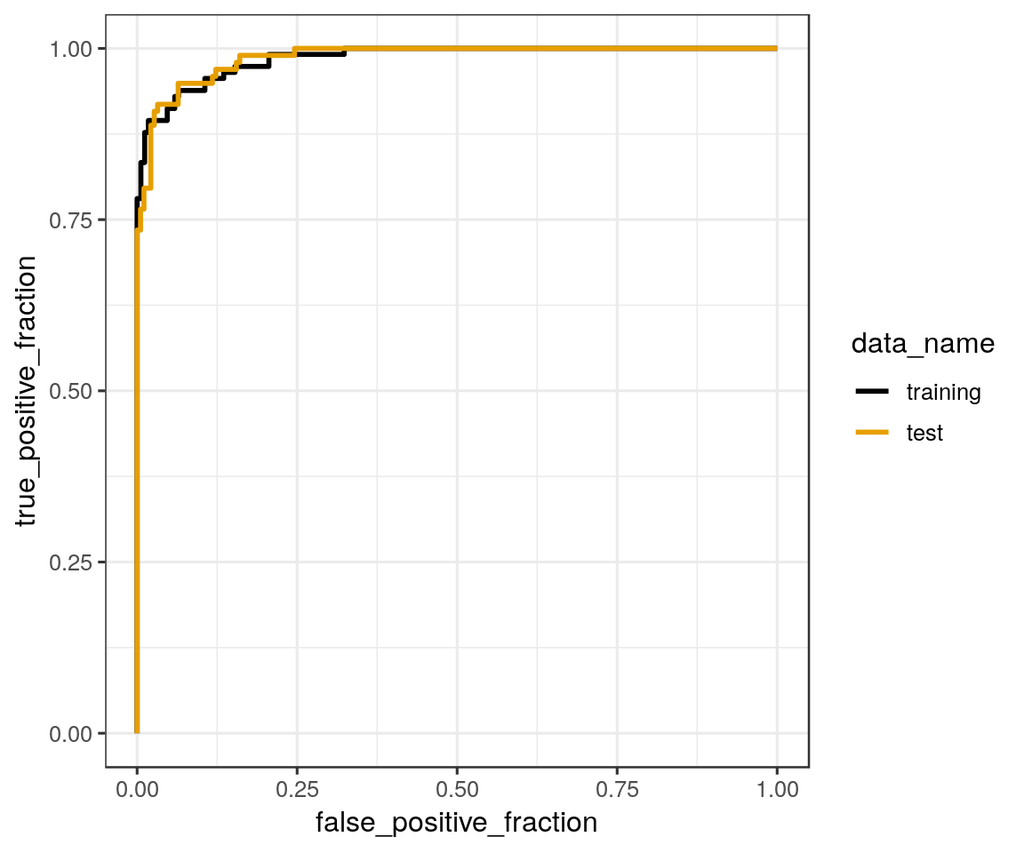

```r
# results data frame for training data
df_train <- data.frame(
predictor = predict(glm_out, train_data),
known_truth = train_data$diagnosis,
data_name = "training"
)
# results data frame for test data
df_test <- data.frame(
predictor = predict(glm_out, test_data),
known_truth = test_data$diagnosis,
data_name = "test"
)
df_combined <- rbind(df_train, df_test)
ggplot(df_combined, aes(d = known_truth, m = predictor, color = data_name)) +
geom_roc(n.cuts = 0) +
scale_color_colorblind()
```

After looking at ROC curves we see that the model fits and predicts quite well on the data. Even the AUC values say the same thing that model is really good on both the training and test data.

```r
p <- ggplot(df_combined, aes(d = known_truth, m = predictor, color = data_name)
) +
geom_roc(n.cuts = 0)
data_name <- unique(df_combined$data_name)
data_info <- data.frame(
data_name,
group = order(data_name)
)
left_join(data_info, calc_auc(p)) %>%
select(-group, -PANEL) %>%
arrange(desc(AUC))
```

```
##   data_name       AUC
## 1      test 0.9865219
## 2  training 0.9856037
```

So by fitting the model and testing it, we see that the model performs really good. This is because the diagnosis is dependent on the following three features: texture of the nuclei image , area of the nuclei , concave points. This is true because we identify cancer cells due to irregular nuclei size like large nuclei(area), different texture and the shape is not circular so cells have many concave points. Thus we found out the important features for diagnosis of breast cancer.